# Dislike Data MLR

Author

Nicholas Fisher

# 1 Introduction

Can the number of dislikes on a YouTube video be modeled using engagement metrics? Using a dataset of YouTube videos collected between 2004 and 2018, this project investigates whether a multiple linear regression model can reasonably predict the number of dislikes a video may receive based on video engagement characteristics.

One challenge in modeling the dislikes variable is the strong right-skew present in the data. Video popularity varies substantially across the platform, resulting in large differences in views, likes, comments, and dislikes between videos. Additionally, a portion of the videos in the dataset contain zero dislikes, further contributing to the non-normality of the response variable.

The primary goal of this analysis is to develop a model capable of reasonably estimating the expected range of dislikes a video may receive when uploaded to YouTube. To begin the analysis, an initial untransformed multiple linear regression model was constructed using dislikes as the response variable. From there, diagnostic techniques and transformations were explored to improve model assumptions, interpretability, and predictive performance.

# 2 Data Overview

```
Rows: 6,354
Columns: 4
$ likes         <dbl> 57527, 97185, 146033, 10172, 132235, 9763, 15993, 23663,…
$ dislikes      <dbl> 2966, 6146, 5339, 666, 1989, 511, 2445, 778, 119, 1363, …
$ comment_count <dbl> 15954, 12703, 8181, 2146, 17518, 1434, 1970, 3432, 340, …
$ views         <int> 748374, 2418783, 3191434, 343168, 2095731, 119180, 21034…
```

## 2.1 Reviewing Data

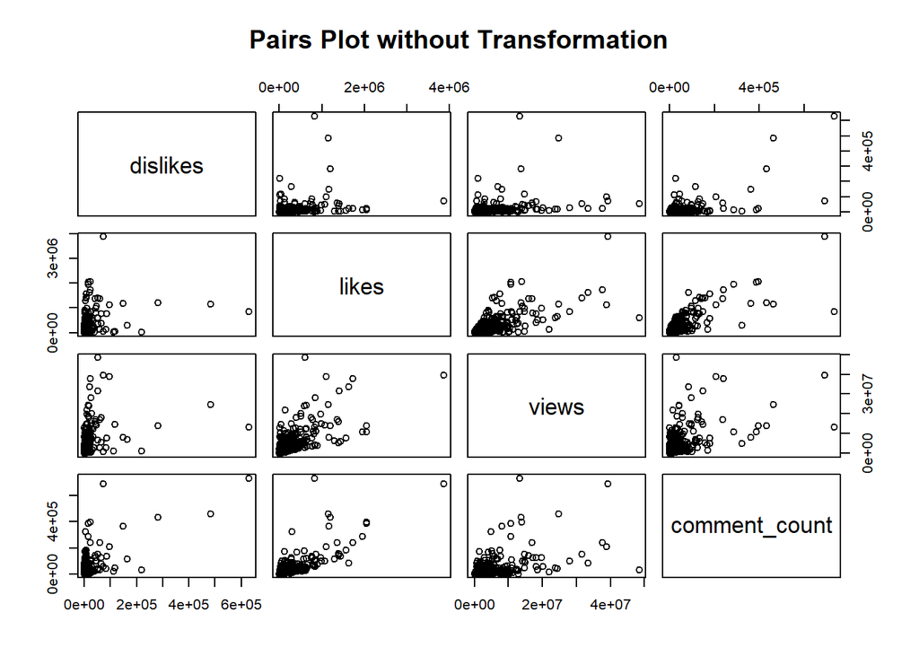

The pairs plot indicates that the relationships between the response variable and predictors are not strongly linear in their original scales. However, the variables generally exhibit a positive association, as larger values of views, likes, and comment counts tend to correspond with larger dislike counts. The plots also reveal substantial right-skewness and clustering near zero, suggesting the presence of non-constant variance and potential nonlinearity. To improve linearity and stabilize variance, all predictor variables will next be examined under logarithmic transformation.

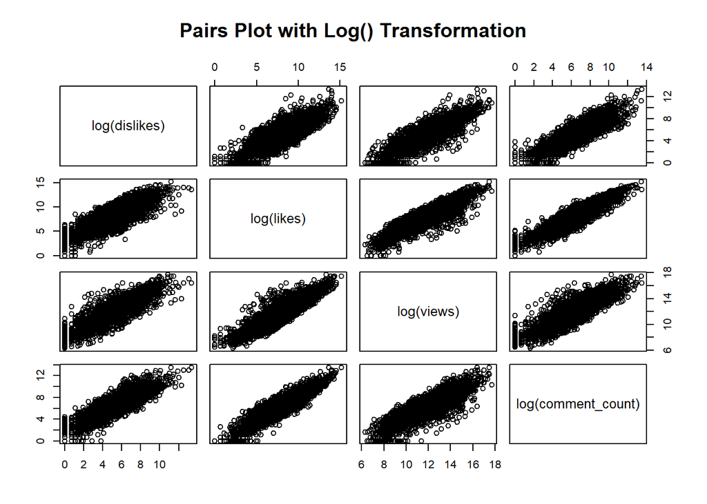

After applying logarithmic transformations to the variables, the relationships between the predictors and response variable exhibit a substantially stronger linear pattern. The transformed variables display improved linearity, reduced skewness, and more consistent variance across the range of observations. These results suggest that the log transformation is more appropriate for modeling the engagement metrics within the dataset. To further evaluate whether a logarithmic transformation of the response variable is appropriate, a Box-Cox transformation analysis will be performed on the dislikes variable.

## 2.2 Box-Cox Transformation

To further motivate the log transformation. This is the full model, I will be using for the Box-Cox Method.

$$\text{dislikes}
=
\beta_0
+
\beta_1
\log(\text{likes})
+
\beta_2
\log(\text{views})
+
\beta3
\log(\text{comment\_count})
+\varepsilon_i$$

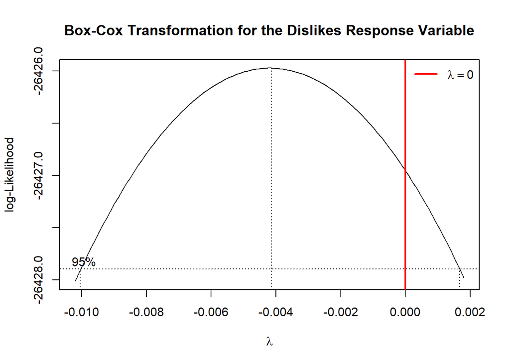

As indicated by the Box-Cox transformation analysis, the estimated transformation parameter is $\lambda = 0$ approximately suggesting that a logarithmic transformation of the response variable is appropriate for the model. Consequently, a log-transformed response variable will be used in the final regression model.

With the transformed model established, the next step is to evaluate the assumptions of multiple linear regression and assess the overall adequacy of the model.

# 3 Regression Diagnostics

## 3.1 Outliers and High Leverage

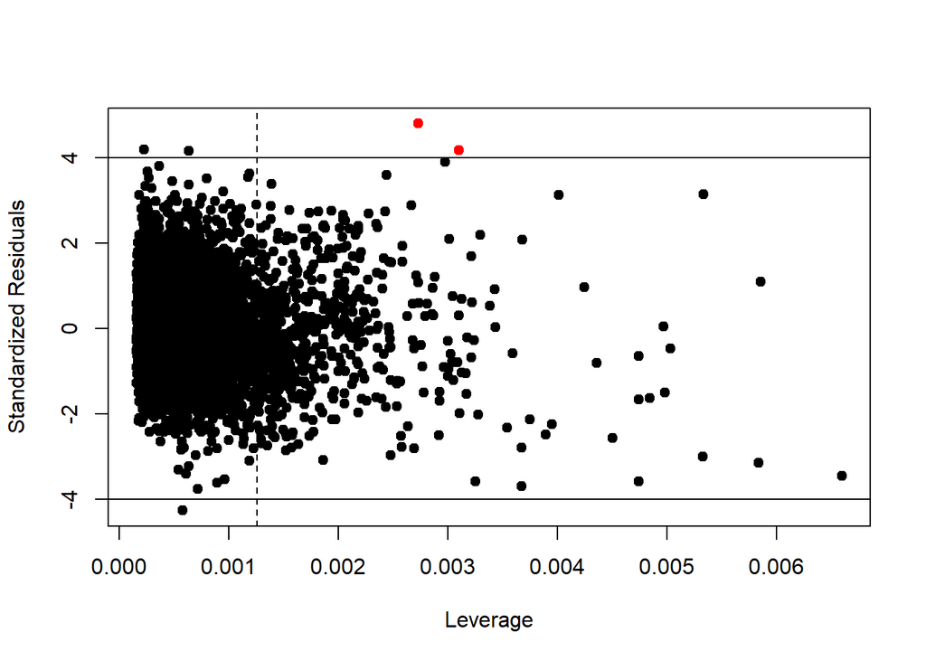

Information of the two high leverage and outlier points highlighted in red.

High Leverage and Outlier Observations

|  | title | channel_title | views | likes | dislikes | comment_count |
| --- | --- | --- | --- | --- | --- | --- |
| 1528 | The FCC repeals its net neutrality rules | Washington Post | 985179 | 4870 | 110707 | 19843 |
| 1740 | PSA from Chairman of the FCC Ajit Pai | Daily Caller | 1142585 | 9100 | 218841 | 28013 |

No removal of the identified high leverage or outlier observations was considered necessary, as these data points still represent valid YouTube video engagement patterns and contribute meaningful information toward modeling dislike counts. Retaining these observations allows the model to better capture the variability and behavior associated with real-world YouTube interactions, including videos with unusually high engagement or audience response.

## 3.2 Linearity

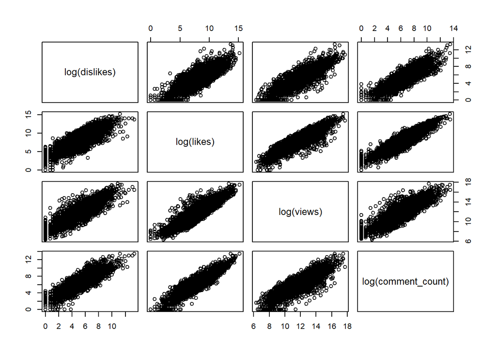

As observed from the pairs plot, the response variable exhibits positive linear relationships with each predictor variable. Additionally, positive associations are present among the predictor variables themselves, indicating that videos with higher engagement in one metric tend to demonstrate higher engagement across other metrics as well.

## 3.3 Independence

Duplicate observations were removed from the dataset by excluding videos that shared the same publication timestamp (YYYY-MM-DD HH:MM:SS.SSS) and title. After removing duplicate observations, the remaining videos were treated as approximately independent observations for the purposes of regression modeling.

## 3.4 Normality

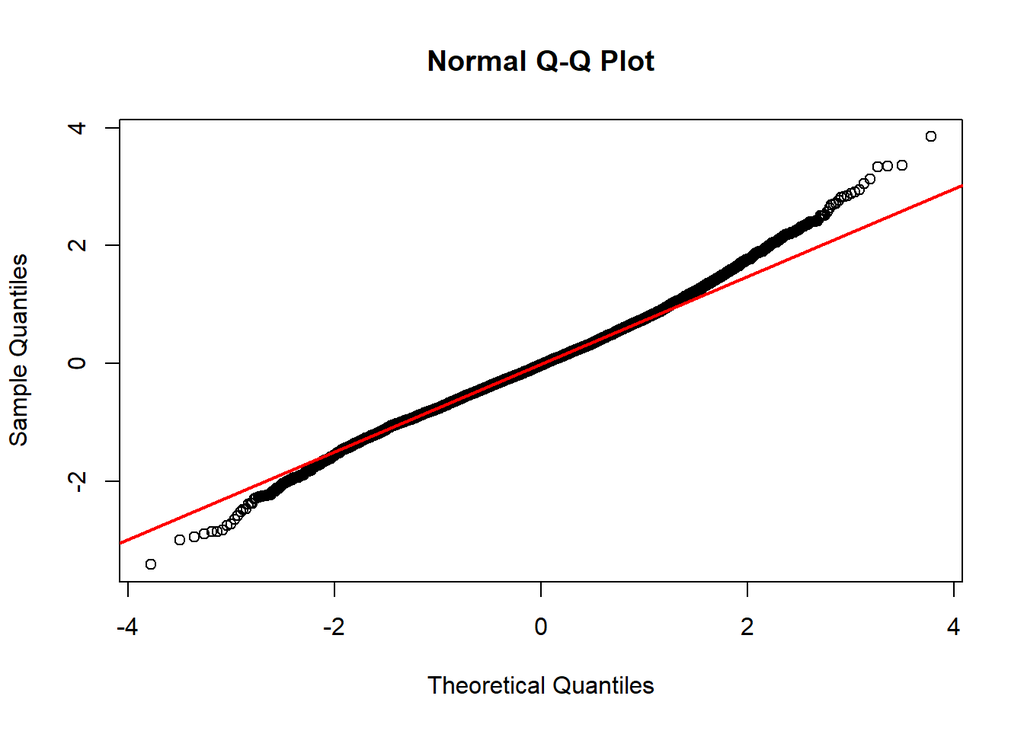

## 3.5 Equal Variance

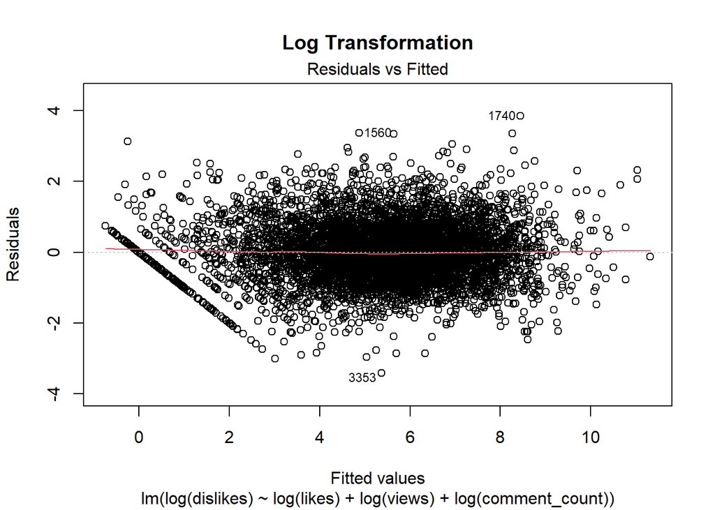

## 3.6 Multicollinearity (VIF)

To further assess the regression assumptions, multicollinearity among the predictor variables was evaluated using the Variance Inflation Factor (VIF). The resulting VIF values were:

```
        log(likes)         log(views) log(comment_count)
          8.017638           4.807447           6.554574
```

Moderate multicollinearity was expected among the engagement predictors, as viral videos that receive high view counts also tend to receive increased likes and comment activity. Consequently, these engagement metrics are naturally correlated within the dataset.

# 4 Final Model

So our final model after collecting the betas for our model is:

$$\log(\text{dislikes})
=
-4.06283
- 0.18455\log(\text{likes})
+ 0.55405\log(\text{views})
+ 0.63115\log(\text{comment\_count})
+ \varepsilon_i$$
Can also be written as:

$$\text{dislikes}
=
e^{-4.06283}
\cdot
\frac{
\text{views}^{0.55405}
(\text{comment\_count}^{0.63115})
}{
\text{likes}^{0.18455}
}
\cdot
e^{\varepsilon_i}$$
The model produced a multiple $R^2$ value of 0.8283, indicating that approximately 82.83% of the variability in log(dislikes) is explained by the predictor variables included in the model. This suggests that the model provides a strong overall fit to the transformed response variable.

We can also observe that, holding all other predictors constant, the estimated number of dislikes increases as views and comments increase, whereas an increase in likes is associated with a decrease in the estimated number of dislikes.

The fitted regression model can now be used to generate predictions and confidence intervals for the expected number of dislikes a YouTube video may receive based on its engagement metrics. By supplying values for predictors such as views, likes, and comment count, the model is able to estimate the expected range of dislikes associated with a video under the transformed regression framework.

# 5 Interactive Prediction Tool

Number of Likes

Number of Comments

Number of Views

# 6 Final Diagnostics

Lastly, a summary table of the final model diagnostics will be presented to provide an overall assessment of the model’s performance, predictive accuracy, and adherence to the assumptions of multiple linear regression.

| Diagnostics | Outputs |
| --- | --- |
| AIC | 15254.82 |
| Adjusted R Squared | 82.83% |
| RMSE | 0.7925 |

*The RMSE value is measured on the log-transformed response scale.

# 7 Concluding Remarks

Because the model only incorporates the number of likes, comments, and views to estimate YouTube video dislikes, there is limited information available to fully capture the underlying factors associated with dislike counts. In practice, additional contextual information would likely improve predictive performance, such as incorporating sentiment analysis of comment text to account for negative language and viewer reactions.

Additionally, some companies and third-party platforms use more robust modeling approaches that are more closely integrated with YouTube data and user interaction patterns, allowing for potentially more accurate dislike estimations.

It is also important to note that the dataset used in this analysis consists primarily of pre-2020 YouTube data. Viewer behavior and platform dynamics have evolved substantially over time, particularly following broader shifts in online moderation practices, public discourse, and user engagement after approximately 2018. As a result, the relationships observed in this model may better reflect patterns of audience sentiment and engagement from an earlier period of YouTube usage, when likes and dislikes may have more directly represented viewer opinion. Consequently, the predictive relationships identified in this analysis may not generalize as effectively to more recent YouTube environments and user behaviors.

Through additional research on methods for estimating YouTube dislike counts, a third-party platform referenced in the appendix was identified that similarly attempts to estimate the number of dislikes associated with videos. Although Return YouTube Dislike and related browser extensions are not officially affiliated with YouTube, they utilize archived dislike statistics and user-generated extension data to approximate dislike counts following YouTube’s removal of public dislike visibility from the platform.

Similar to the predictive framework developed in this analysis, these external tools rely on statistical estimation techniques and observed engagement behavior to approximate the number of dislikes a video may receive. This further demonstrates the ongoing relevance of predictive modeling approaches for understanding audience engagement and interaction patterns on digital media platforms.

# 8 Appendix

## 8.1 References

1. Kaggle. (2018). Trending YouTube Video Statistics. https://www.kaggle.com/datasets/datasnaek/youtube-new?select=USvideos.csv
2. Return YouTube Dislike. (2025). Return YouTube Dislike. https://www.returnyoutubedislike.com/install

## 8.2 Acknowledgment

This project applies multiple linear regression methodologies and diagnostic techniques studied in STAT 633A (Linear Regression) at California State University, East Bay under the instruction of Dr. Kerr during the Spring 2026 semester.